# Réorganisation des données dans R

[Retour à la page d’accueil](https://scortijo.github.io/2026_L3_R/)

Dans cette partie du cours vous allez apprendre à réorganiser des tables dans R. Cela peur être utile si vous ne devez travailler que sur une partie des données.

Aujourd’hui nous allons voir:

1. Comment filtrer des lignes ou des colonnes dans un tableau
2. Exporter le nouveau tableau créé dans R
3. Combiner une filtration de lignes avec un graphique
4. Ajouter ou modifier des colonnes

# Mise en place

Tout d’abord, créez un nouveau *script R* et préparez votre environnement de travail:

```r
# Chargez la librairie `tidyverse` (aide: utilisez la fonction `library()`)

# Changez votre répertoire de travail pour être dans `session3_plots_reorganisation`
#(aide: utilisez la fonction `setwd()`)

# Importer `burghardt_et_al_2015_expt1.txt` et mettez le dans un objet appelé `expt1`
#(aide: utilisez la fonction `read_tsv()`)
```

# Sélectionner des colonnes avec la fonction `select()`

Tout d’abord, utilisons les fonctions `dim()` et `names()` afin de connaitre les dimensions du tableau et le nom des colonnes.

```r
dim(expt1)
```

```
## [1] 957  15
```

```r
names(expt1)
```

```
##  [1] "plant_nb"             "genotype"             "background"
##  [4] "temperature"          "fluctuation"          "day.length"
##  [7] "vernalization"        "bolt.survival"        "bolt"
## [10] "days.to.bolt"         "days.to.flower"       "rosette.leaf.num"
## [13] "cauline.leaf.num"     "blade.length.mm"      "total.leaf.length.mm"
```

Il y a beaucoup de colonnes dans ce tableau. Afin de ne garder que les colonnes `genotype` et `temperature`, nous pouvons utiliser la fonction `select()`

```r
select(expt1, genotype, temperature)
```

```
## # A tibble: 957 × 2
##    genotype temperature
##    <chr>          <dbl>
##  1 Col Ama           12
##  2 Col Ama           12
##  3 Col Ama           12
##  4 Col Ama           12
##  5 Col Ama           12
##  6 Col Ama           12
##  7 Col Ama           12
##  8 Col Ama           12
##  9 Col Ama           12
## 10 Col Ama           12
## # ℹ 947 more rows
```

Il est aussi possible de ne garder que les colonnes qui contiennent le mot “bolt” dans leur nom:

```r
select(expt1, contains("bolt"))
```

```
## # A tibble: 957 × 3
##    bolt.survival bolt  days.to.bolt
##    <chr>         <chr>        <dbl>
##  1 Y             Y               28
##  2 Y             Y               29
##  3 Y             Y               31
##  4 Y             Y               31
##  5 Y             Y               32
##  6 Y             Y               33
##  7 Y             Y               34
##  8 Y             Y               35
##  9 Y             Y               69
## 10 Y             Y               72
## # ℹ 947 more rows
```

> **Exercice 1** : Sélectionnez les colonnes qui contiennent des données mesurées en mm

> **BONUS**:  
> 1. Sélectionnez les colonnes dont le titre finit par “bolt”  
> 2. Sélectionnez les colonnes qui ne sont pas `plant_nb` et `genotype`  
> *Aide*: Regardez les exemples dans l’aide de R ou cherchez dans google

# Sélectionner des lignes à partir de critères avec la fonction `filter()`

Avec la fonction `filter()`, nous pouvons garder toutes les lignes de notre table qui correspondent à des plantes qui ont subies une vernalisation.

Tout d’abord, nous devons connaitre les différentes valeurs de la colonne `vernalization`. Comme nous pouvons voir, il y a deux options: ‘NV’ et ‘V’.

```r
distinct(expt1, vernalization)
```

```
## # A tibble: 2 × 1
##   vernalization
##   <chr>
## 1 NV
## 2 V
```

Comme nous voulons garder les plantes qui ont subies une vernalisation, nous devons filtrer les données pour garder les lignes pour lesquelles il y a “V” dans la colonne `vernalization`:

```r
filter(expt1, vernalization == "V")
```

```
## # A tibble: 330 × 15
##    plant_nb genotype background temperature fluctuation day.length vernalization
##       <dbl> <chr>    <chr>            <dbl> <chr>            <dbl> <chr>
##  1        1 Col Ama  Col                 12 Con                 16 V
##  2        2 Col Ama  Col                 12 Con                 16 V
##  3        3 Col Ama  Col                 12 Con                 16 V
##  4        4 Col Ama  Col                 12 Con                 16 V
##  5        5 Col Ama  Col                 12 Con                 16 V
##  6        6 Col Ama  Col                 12 Con                 16 V
##  7        7 Col Ama  Col                 12 Con                 16 V
##  8        8 Col Ama  Col                 12 Con                 16 V
##  9        1 Col Ama  Col                 12 Con                  8 V
## 10        2 Col Ama  Col                 12 Con                  8 V
## # ℹ 320 more rows
## # ℹ 8 more variables: bolt.survival <chr>, bolt <chr>, days.to.bolt <dbl>,
## #   days.to.flower <dbl>, rosette.leaf.num <dbl>, cauline.leaf.num <dbl>,
## #   blade.length.mm <dbl>, total.leaf.length.mm <dbl>
```

Nous pouvons utiliser les opérateurs suivant pour définir les conditions pour filtrer les données:

| Opérateur | Condition de sélection | Exemple |
| --- | --- | --- |
| `<` | inférieur à | `filter(expt1, days.to.bolt < 20)` |
| `<=` | inférieur ou égal à | `filter(expt1, days.to.bolt <= 20)` |
| `>` | supérieur à | `filter(expt1, days.to.bolt > 20)` |
| `>=` | supérieur ou égal à | `filter(expt1, days.to.bolt >= 20)` |
| `==` | égal à | `filter(expt1, days.to.bolt == 20)` |
| `!=` | différent de | `filter(expt1, days.to.bolt != 20)` |
| `%in%` | est contenu dans | `filter(expt1, genotype %in% c("Col FRI", "Ler-1"))` |

Il est aussi possible de combiner plusieurs conditions de sélection avec les opérateurs suivant:

| Opérateur | Signification | Exemple |
| --- | --- | --- |
| `&` | ET | `filter(expt1, days.to.bolt == 20 & genotype == "Ler-1")` |
| `\|` | OU | `filter(expt1, rosette.leaf.num < 8 \| rosette.leaf.num > 100)` |

Nous pouvons aussi identifier les données manquantes (`NA`) avec la fonction `is.na()` ou sa négation (en utilisant `!`):

| Opérateur | Signification | Exemple |
| --- | --- | --- |
| `is.na()` | données manquante | `filter(expt1, is.na(rosette.leaf.num))` |
| `!is.na()` | donnée *non* manquante | `filter(expt1, !is.na(rosette.leaf.num))` |

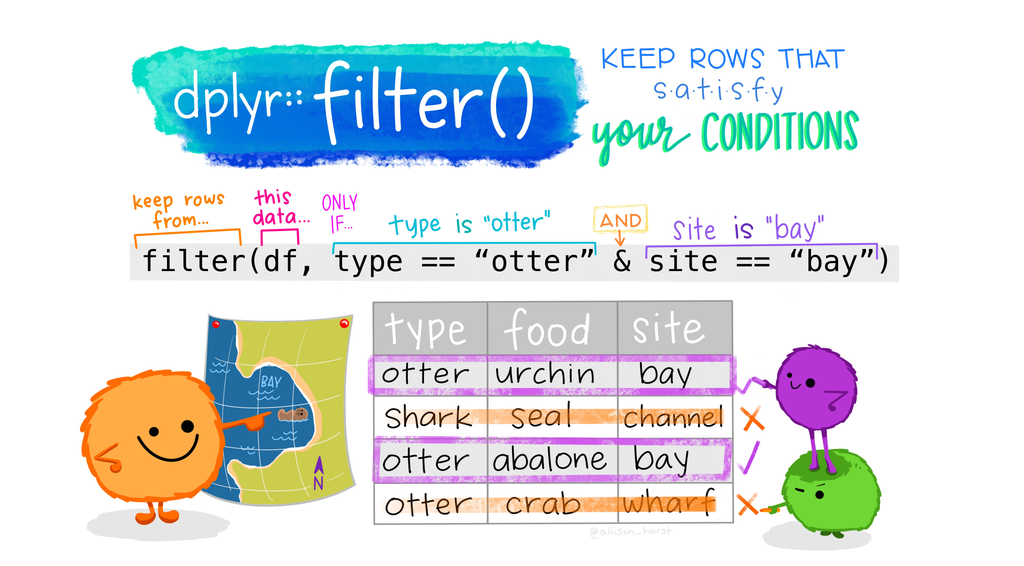

[source de l’image](https://github.com/allisonhorst/stats-illustrations)

Par exemple, nous pouvons sélectionner les plantes qui ont été vernalisées **ET** qui ont poussées avec une température fluctuante:

```r
filter(expt1, vernalization == "V" & fluctuation == "Var")
```

Il est aussi possible de sélectionner les plantes qui ont poussées avec 8h de jours **OU** qui fleurissent tardivement:

```r
filter(expt1, day.length == "8" | days.to.bolt > 85)
```

> **Exercice 2:** Filtrez les données pour garder les plantes selon les 3 cas de figures suivant (indépendants les uns des autres):
> 1. Plantes qui **ne sont pas du background Ler** et qui ont été traitées avec **une température fluctuante**.
> 2. Plantes qui ont fleuries (bolt) en moins de **57 jours** et qui ont **moins de 40 feuilles de rosette**
> 3. Plantes du génotype **fca-6** pour qui le **blade.length.mm n’est pas manquant**

> **BONUS**:  
> Filtrez les données pour garder les lignes pour lesquelles le background contient **Col**  
> Sauvez le résultat dans un nouvel objet et vérifier quelles valeurs distinctes sont dans la colonne background en utilisant le fonction `distinct()`  
> *Aide*: Faites un recherche sur google pour trouver le résultat

# Exporter le nouveau tableau créé dans R

Aujourd’hui, nous avons fortement restructuré notre tableau. Nous pouvons le sauver pour le réutiliser ultérieurement.

Pour cela nous utilisons la fonction `write_tsv()`

Par exemple, imaginons que nous voulons enlever des données manquantes et partager les données avec un collaborateurs (ou les réutiliser nous même plus tard):

```r
expt1.days.to.flower.clean <- expt1 %>%
  filter(!is.na(days.to.flower))

write_tsv(expt1.days.to.flower.clean, file = "../data/expt1_days_to_flower_clean.txt")
```

# Combiner des sélections de lignes avec un graphique

Afin de pouvoir combiner la sélection de données avec un graphique, nous devons d’abord apprendre à faire des chaines de commandes.

## Créer des chaînes de commandes avec les pipes `%>%`

Les “pipes” (`%>%`) permettent de faire une séquence d’opération sur des données, sans avoir besoin de créer des objets intermédiaires (ou de faire des commandes imbriquées très compliquées)

Imaginons que nous voulions faire les sélections suivantes sur notre table:

- Filtrer des données pour ne garder que les plantes qui ont été vernalisées
- Ne garder que deux colonnes: le génotype et la taille totale des feuilles

Grace au symbole `%>%` pipe, nous pouvons créer une chaîne de commandes. Pour cela nous devons d’abord faire une commande et ajouter `%>%` à la fin de la ligne qui va utiliser le résultat de cette commande comme input pour la fonction à la ligne suivante. Voici comment faire:

```r
expt1 %>%
  filter(vernalization == "V") %>%
  select(genotype, total.leaf.length.mm)
```

```
## # A tibble: 330 × 2
##    genotype total.leaf.length.mm
##    <chr>                   <dbl>
##  1 Col Ama                  22.1
##  2 Col Ama                  26.8
##  3 Col Ama                  27.9
##  4 Col Ama                  22.8
##  5 Col Ama                  24.9
##  6 Col Ama                  22.2
##  7 Col Ama                  24.1
##  8 Col Ama                  21.4
##  9 Col Ama                  36
## 10 Col Ama                  29.9
## # ℹ 320 more rows
```

> **Exercice 3:** Utilisez `%>%` pour faire la suite de sélections suivantes sur `expt1`:
> - Gardez les plantes qui *ne sont pas* du background Ler, et qui ont été traitées avec la température fluctuante.
> - Ne gardez que les colonnes qui contiennent le génotype, la longueur de “blade” et des information sur le “bolting”

> **BONUS**: Transformez l’enchainement de commandes afin d’utiliser des pipes `%>%` plutôt que objets intermédiaires

```r
expt1 <- read_tsv("../data/burghardt_et_al_2015_expt1.txt")

expt1_filtered <- filter(expt1, fluctuation=="Con" & day.length=="16")

expt1_selected <- select(expt1_filtered,days.to.bolt:total.leaf.length.mm)

summary(expt1_selected)
```

```
##   days.to.bolt    days.to.flower  rosette.leaf.num cauline.leaf.num
##  Min.   : 15.00   Min.   : 21.0   Min.   : 6.00    Min.   : 1.000
##  1st Qu.: 26.75   1st Qu.: 39.0   1st Qu.:14.00    1st Qu.: 4.000
##  Median : 41.50   Median : 49.0   Median :30.00    Median : 7.000
##  Mean   : 45.00   Mean   : 53.6   Mean   :31.67    Mean   : 6.827
##  3rd Qu.: 57.00   3rd Qu.: 70.0   3rd Qu.:46.00    3rd Qu.: 9.000
##  Max.   :152.00   Max.   :135.0   Max.   :91.00    Max.   :13.000
##                   NA's   :7       NA's   :9        NA's   :9
##  blade.length.mm total.leaf.length.mm
##  Min.   : 8.20   Min.   :10.90
##  1st Qu.:14.45   1st Qu.:22.12
##  Median :19.20   Median :30.50
##  Mean   :18.39   Mean   :29.01
##  3rd Qu.:21.57   3rd Qu.:34.52
##  Max.   :28.20   Max.   :47.00
##  NA's   :78      NA's   :62
```

## Combiner avec un graphique

Avec le pipe nous pouvons aussi utiliser l’output d’une commande (ou d’une chaîne de commandes) comme un input pour `ggplot` afin de faire un graphique sur les données sélectionnées. Ceci est très utile lors de la phase d’exploration des données (sans avoir à créer de nouveaux objets avec en permanence `<-`).

Nous pouvons par exemple faire un box plot pour le temps de floraison en fonction de la fluctuation de température, mais celle fois uniquement pour les plantes qui ont été vernalisées:

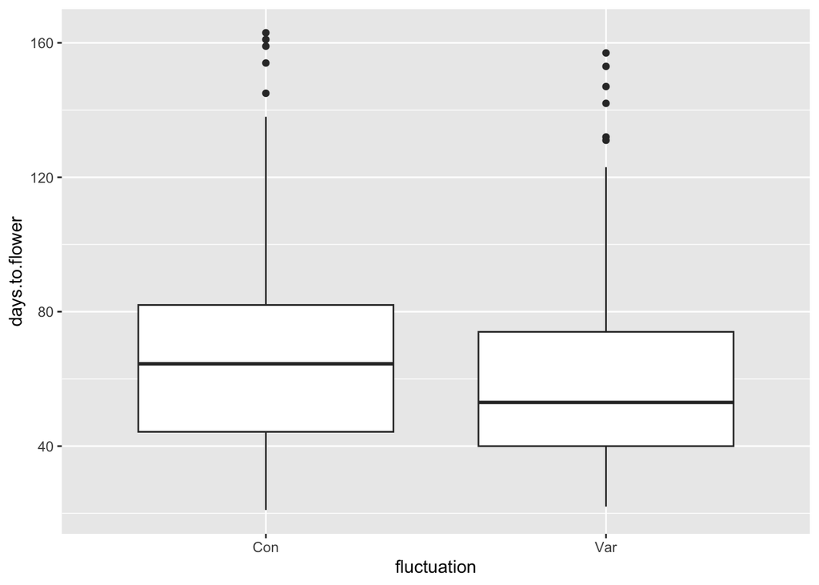

```r
expt1 %>%
  filter(vernalization == "V") %>%
  ggplot(aes(fluctuation, days.to.flower)) +
  geom_boxplot()
```

> **Exercice 4:** Faite un violon plot du temps de floraison pour les différents génotypes, mais uniquement pour les plantes ayant poussées en jours court (8h de lumière).

> Aide: Utilisez `filter()` pour sélectionner les données et ensuite un pipe (`%>%`) pour utiliser l’output pour le graphique.

> **BONUS**

> Représentez, uniquement pour les plantes qui contiennent le mot “Col” dans le background, et qui ont poussée à 22°C, un box plot de *days.to.bolt* en fonction du *vernalization*, coloré en fonction de la *fluctuation*. Séparez les graphiques pour avoir une facet par *génotype*. Utilisez un thème de type *theme_bw*.

> **Interprétez le résultat** Est-ce que le temps de floraison de certains génotypes est affecté par la fluctuation de température. Si oui lesquels?

# Modifier ou ajouter des colonnes avec `mutate()`

La fonction `mutate()` permet d’ajouter de nouvelles variables (i.e. nouvelles colonnes) dans une table, ou de modifier des colonnes déjà existantes.

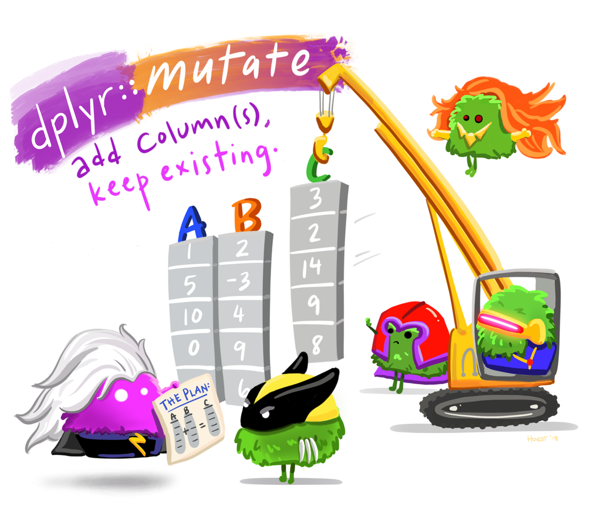

[source de l’image](https://github.com/allisonhorst/stats-illustrations)

```r
# Créez une nouvelle table avec la colonne supplémentare
expt1.cm <- mutate(expt1, total.leaf.length.cm = total.leaf.length.mm/10)

# Vérifier que la nouvelle colonne est bien là
colnames(expt1.cm)
```

```
##  [1] "plant_nb"             "genotype"             "background"
##  [4] "temperature"          "fluctuation"          "day.length"
##  [7] "vernalization"        "bolt.survival"        "bolt"
## [10] "days.to.bolt"         "days.to.flower"       "rosette.leaf.num"
## [13] "cauline.leaf.num"     "blade.length.mm"      "total.leaf.length.mm"
## [16] "total.leaf.length.cm"
```

Nous pouvons aussi créer et modifier plus d’une colonne à la fois, en les séparant par une virgule (`,`) dans la fonction `mutate()`:

```r
# Créez deux nouvelles colonnes
expt1.cm <- mutate(expt1,
                   blade.length.cm = blade.length.mm/10,
                   total.leaf.length.cm = total.leaf.length.mm/10)

# Vérifier que les nouvelles colonnes sont bien là
colnames(expt1.cm)
```

```
##  [1] "plant_nb"             "genotype"             "background"
##  [4] "temperature"          "fluctuation"          "day.length"
##  [7] "vernalization"        "bolt.survival"        "bolt"
## [10] "days.to.bolt"         "days.to.flower"       "rosette.leaf.num"
## [13] "cauline.leaf.num"     "blade.length.mm"      "total.leaf.length.mm"
## [16] "blade.length.cm"      "total.leaf.length.cm"
```

**Attention!!** Si vous utilisez le nom d’une colonne déjà existante, vous allez la modifier et non créer une nouvelle colonne.

> **Exercice 5:**

> Créez une nouvelle colonne “blade.ratio” avec le ratio de `blade.length.mm` et `total.leaf.length.mm`

> **BONUS:**  
> Créez une nouvelle colonne “late.flowering” qui contient `TRUE` si days.to.bolt est supérieur à 70, et `FALSE` days.to.bolt est inférieur à 70.  
> *Aide*: Trouvez la solution en utilisant google

## Ressources et liens utiles:

- [Chapitre sur la réorganisation de données du livre ‘R for Data Science’](http://r4ds.had.co.nz/transform.html)

# Contrôle continu à faire pour la prochaine séance

[Retour à la page d’accueil](https://scortijo.github.io/2026_L3_R/)